# analysis of bottom trawl samples using mifish primers

Kimberly Ledger

2023-07-05

data from miseq run 23 June 2023 - included picogreen quantificaiton and normalization by hand during library prep  
**the ASVS/samples have not been decontaminated** this is just a quick preliminary look at the samples

load libraries

```r
library(tidyverse)
```

```r
library(ggplot2)
```

read in taxonomic identification table - from BLASTN assignmnet

```r
# taxons_blast <- read.csv("/genetics/edna/workdir/bottomtrawl_2022/20230310/trimmed/filtered/outputs/asv_taxonomy_blastn.csv", row.names = 1) %>%
#   rename(taxon_blast = taxon) %>%
#   rename(rank_blast = taxonomic_level)
```

read in taxonomic identification table - from INSECT assignmnet

```r
taxons_insect <- read.csv("/genetics/edna/workdir/bottomtrawl_2022/20230623/trimmed/filtered/outputs/asv_full_taxonomy_insect.csv", row.names = 1) %>%
  filter(class != "Mammalia") %>%
  filter(taxon != "root") %>%
  select(representative, taxon, rank) %>%
  rename(ASV = representative) %>%
  rename(taxon_insect = taxon) %>%
  rename(rank_insect = rank)
```

compare blast and insect taxonomies

```r
# taxons <- taxons_insect %>%
#   left_join(taxons_blast, by = "ASV")
#
# head(taxons)
```

read in samples by asv table

```r
asv_table <- read.csv("/genetics/edna/workdir/bottomtrawl_2022/20230623/trimmed/filtered/outputs/ASVtable.csv") %>%
  rename(SampleID = X)
```

join taxon and asv table

```r
read_summary <- asv_table %>%
  pivot_longer(cols = starts_with("ASV"), names_to = "ASV", values_to = "count") %>%
  left_join(taxons_insect, by = "ASV") %>%
  filter(count > 0) %>%
  filter(taxon_insect != "NA") %>%
  group_by(SampleID, taxon_insect) %>%
  summarise(total_read_count = sum(count)) %>%
  pivot_wider(names_from = "taxon_insect", values_from = "total_read_count") %>%
  replace(is.na(.), 0)
```

pivot longer – **remember to change column numbers when using new data sets**

```r
read_summary_long <- read_summary %>%
  pivot_longer(cols = 2:75, names_to = "taxon", values_to = "reads") %>%
  mutate(reads = ifelse(is.na(reads), 0, reads))
```

read in bottom trawl metadata and join

```r
metadata <- read.csv("/genetics/edna/workdir/bottomtrawl_2022/20230623/bottomtrawl_metadata_20230623.csv") %>%
  unite("SampleID", sampleID:replicate, sep = "-", remove = FALSE) %>%
  select(!X)

bt <- metadata %>%
  left_join(read_summary_long, by = c("SampleID"))
```

## first, let’s look at the extraction blanks

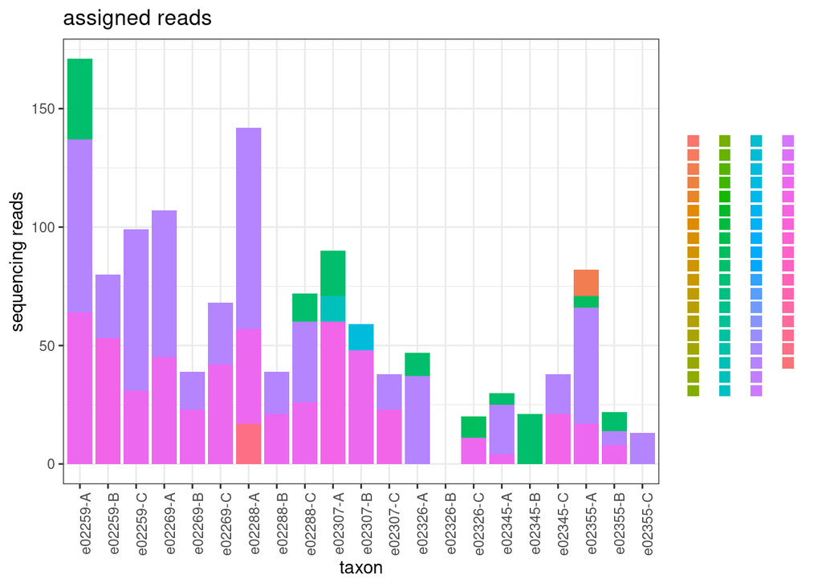

```r
bt %>%
  filter(sample_type == "extraction_blank") %>%
  ggplot(aes(x= SampleID, y = reads, fill = taxon)) +
  geom_bar(stat = "identity") +
  theme_bw() +
  labs(
    y = "sequencing reads",
    x = "taxon",
    title = "assigned reads") +
  theme(
    axis.text.x = element_text(angle = 90, hjust = 0.95),
    legend.text = element_blank(),
    #legend.text = element_text(size = 8),
    legend.key.size = unit(0.3, "cm"),
    legend.position = "right",
    legend.title = element_blank()
  )
```

okay, not too many reads in extraction blanks…

## let’s look at the pcr blanks

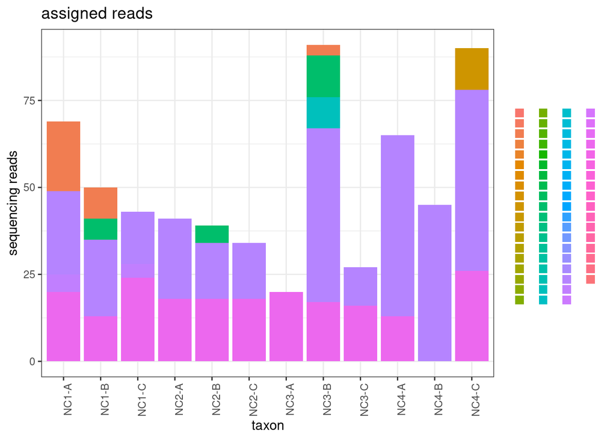

```r
bt %>%
  filter(sample_type == "PCR_blank") %>%
  ggplot(aes(x= SampleID, y = reads, fill = taxon)) +
  geom_bar(stat = "identity") +
  theme_bw() +
  labs(
    y = "sequencing reads",
    x = "taxon",
    title = "assigned reads") +
  theme(
    axis.text.x = element_text(angle = 90, hjust = 0.95),
    legend.text = element_blank(),
    #legend.text = element_text(size = 8),
    legend.key.size = unit(0.3, "cm"),
    legend.position = "right",
    legend.title = element_blank()
  )
```

okay, not too many reads in pcr blanks…

## second, let’s look at the positive control

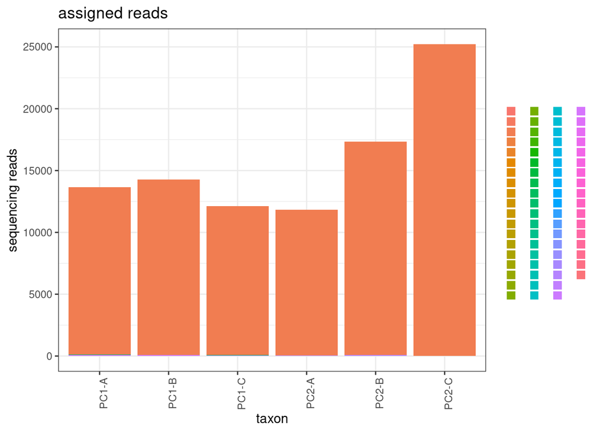

```r
bt %>%
  filter(sample_type == "positive_control") %>%
  ggplot(aes(x= SampleID, y = reads, fill = taxon)) +
  geom_bar(stat = "identity") +
  theme_bw() +
  labs(
    y = "sequencing reads",
    x = "taxon",
    title = "assigned reads") +
  theme(
    axis.text.x = element_text(angle = 90, hjust = 0.95),
    legend.text = element_blank(),
    #legend.text = element_text(size = 8),
    legend.key.size = unit(0.3, "cm"),
    legend.position = "right",
    legend.title = element_blank()
  )
```

good, lots of lake sturgeon here (Acipenser fulvescens)

## next, let’s check the field blanks

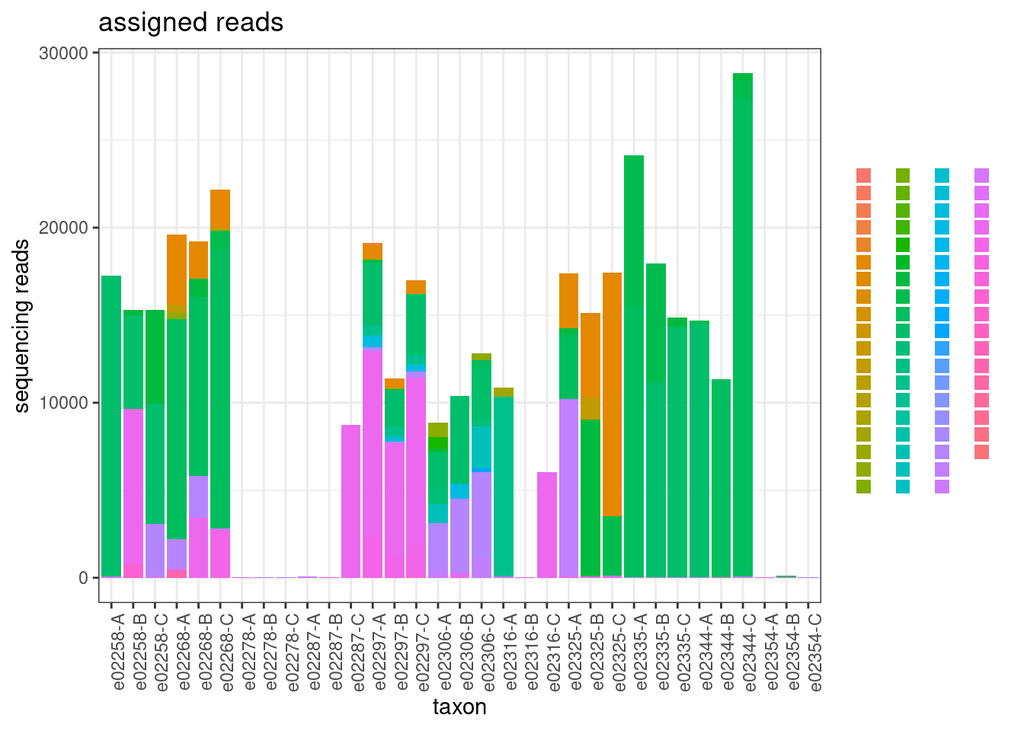

```r
bt %>%
  filter(sample_type == "field_blank") %>%
  ggplot(aes(x= SampleID, y = reads, fill = taxon)) +
  geom_bar(stat = "identity") +
  theme_bw() +
  labs(
    y = "sequencing reads",
    x = "taxon",
    title = "assigned reads") +
  theme(
    axis.text.x = element_text(angle = 90, hjust = 0.95),
    legend.text = element_blank(),
    #legend.text = element_text(size = 8),
    legend.key.size = unit(0.3, "cm"),
    legend.position = "right",
    legend.title = element_blank()
  )
```

okay, some contamination in field blanks.

```r
bt %>%
  filter(sample_type == "field_blank") %>%
  filter(reads > 0) %>%
  group_by(taxon) %>%
  summarize(total_reads = sum(reads)) %>%
  arrange(desc(total_reads))
```

```
## # A tibble: 26 × 2
##    taxon                       total_reads
##    <chr>                             <int>
##  1 Gadus chalcogrammus               96951
##  2 Gadus macrocephalus               88450
##  3 Sebastes                          54417
##  4 Atheresthes                       32270
##  5 Gadus                             21242
##  6 Pleurogrammus monopterygius       20208
##  7 Gadidae                           17235
##  8 Hemilepidotus                     11878
##  9 Pleuronectidae                    11808
## 10 Sebastes crameri                   8292
## # ℹ 16 more rows
```

field contamination is a lot of Gadus, Sebastes, etc…

## third, let’s check out the field samples

make a general plot for read counts

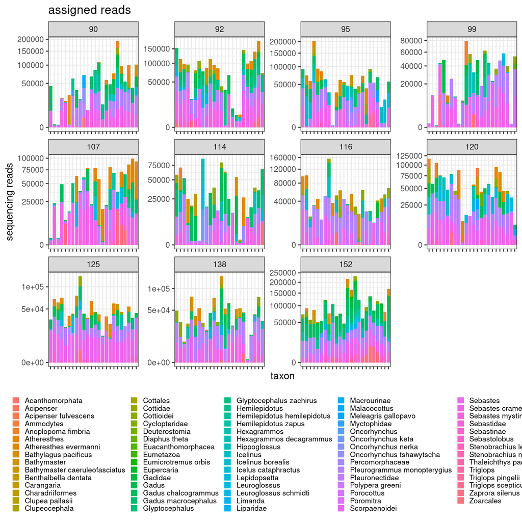

```r
bt %>%
  filter(sample_type == "sample") %>%
  ggplot(aes(x= SampleID, y = reads, fill = taxon)) +
  geom_bar(stat = "identity") +
  scale_y_sqrt() +
  facet_wrap(~station, scales = 'free', ncol = 4) +
  theme_bw() +
  labs(
    y = "sequencing reads",
    x = "taxon",
    title = "assigned reads") +
  theme(
    #axis.text.x = element_text(angle = 90, hjust = 0.95),
    axis.text.x = element_blank(),
    legend.text = element_text(size = 8),
    legend.key.size = unit(0.3, "cm"),
    legend.position = "bottom",
    legend.title = element_blank()
  )
```

## summary table of species reads for field samples

```r
summary <- bt %>%
  filter(sample_type == "sample") %>%
  group_by(taxon) %>%
  summarize(read_count = sum(reads)) %>%
  arrange(desc(read_count))

library(rmarkdown)
f <- function() {
  paged_table(summary)
}

f()
```

| taxon | read_count |
| --- | --- |
| Pleurogrammus monopterygius | 1114460 |
| Sebastes | 852850 |
| Sebastes crameri | 443818 |
| Gadus macrocephalus | 343731 |
| Atheresthes | 159580 |
| Lepidopsetta | 124629 |
| Gadus chalcogrammus | 108004 |
| Hemilepidotus | 79555 |
| Hippoglossus | 66608 |
| Zaprora silenus | 63489 |

[output cut: 64 more lines]

## does known contamination from previous libraries still exist??

** Centrarchoidei (suborder) are sunfish (Centrarchidae) which are freshwater and include large mouth bass… ** Ictalurus == catfish ** Micropterus salmoides == largemouth bass ** Characiphysae - perhaps related to catfish

```r
bt %>%
  filter(taxon == "Centrarchoidei") %>%
  filter(taxon == "Ictalurus") %>%
  filter(taxon == "Micropterus salmoides") %>%
  filter(taxon == "Characiphysae")
```

```
##  [1] SampleID            sampleID            replicate
##  [4] station             sample_rep          sample_type
##  [7] extraction_initials extraction_date     DNA_plate
## [10] plate_well          PCR_plate           vol_longmire
## [13] taxon               reads
## <0 rows> (or 0-length row.names)
```

no, whoop!

just glancing at it, how similar to pcr replicates look?

start with station 90

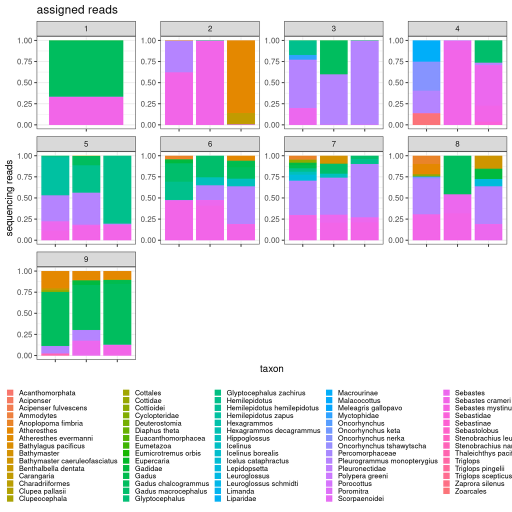

```r
bt %>%
  filter(station == 90) %>%
  group_by(SampleID) %>%
  mutate(sum=sum(reads)) %>%
  mutate(prop = reads/sum) %>%
  filter(sum > 1000) %>%
  ggplot(aes(x= SampleID, y = prop, fill = taxon)) +
  geom_bar(stat = "identity") +
  facet_wrap(~sample_rep, scales = 'free', ncol = 4) +
  theme_bw() +
  labs(
    y = "sequencing reads",
    x = "taxon",
    title = "assigned reads") +
  theme(
    #axis.text.x = element_text(angle = 90, hjust = 0.95),
    axis.text.x = element_blank(),
    legend.text = element_text(size = 8),
    legend.key.size = unit(0.3, "cm"),
    legend.position = "bottom",
    legend.title = element_blank()
  )
```

start with station 95

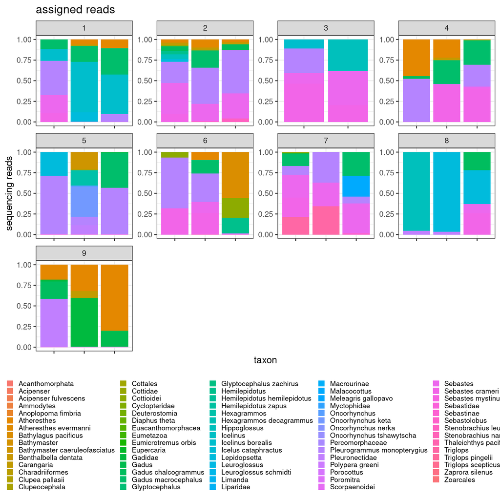

```r
bt %>%
  filter(station == 95) %>%
  group_by(SampleID) %>%
  mutate(sum=sum(reads)) %>%
  mutate(prop = reads/sum) %>%
  filter(sum > 1000) %>%
  ggplot(aes(x= SampleID, y = prop, fill = taxon)) +
  geom_bar(stat = "identity") +
  facet_wrap(~sample_rep, scales = 'free', ncol = 4) +
  theme_bw() +
  labs(
    y = "sequencing reads",
    x = "taxon",
    title = "assigned reads") +
  theme(
    #axis.text.x = element_text(angle = 90, hjust = 0.95),
    axis.text.x = element_blank(),
    legend.text = element_text(size = 8),
    legend.key.size = unit(0.3, "cm"),
    legend.position = "bottom",
    legend.title = element_blank()
  )
```

## at least at this first look, the pcr reps do not look as similar as i’d like… but more data processing and better tax ids are needed before making a call on this. - let’s do decontamination first, then come back